# Demo of spaCy for Python

**spaCy** is an open-source software library for advanced natural language processing, written in the programming languages Python and Cython.

```python
import spacy
from collections import Counter

model = "en_core_web_lg"
nlp = spacy.load(model)
```

# Word frequency

```python
excerpt = "Philippine billionaire Enrique Razon will acquire a 25% stake in Manila Water Co. Inc. ahead of the water company’s contract negotiations with the government. \n \nRazon’s Prime Metroline Holdings Inc. will pay 10.7 billion pesos ($210 million) for 820 million shares at 13 pesos each, Manila Water said in a stock exchange disclosure on Monday."
```

```python
print(excerpt)
```

```
Philippine billionaire Enrique Razon will acquire a 25% stake in Manila Water Co. Inc. ahead of the water company’s contract negotiations with the government.

Razon’s Prime Metroline Holdings Inc. will pay 10.7 billion pesos ($210 million) for 820 million shares at 13 pesos each, Manila Water said in a stock exchange disclosure on Monday.
```

```python
# to make a spaCy document object from text, just call
doc = nlp(excerpt)

# all tokens that arent stop words or punctuations
words = [token.text for token in doc if token.is_stop != True and token.is_punct != True]

# Counter object for the list of words
word_freq = Counter(words)
```

```python
for wf in word_freq.most_common(5):
    print(wf)
```

```
('Razon', 2)
('Manila', 2)
('Water', 2)
('Inc.', 2)
('pesos', 2)
```

# Named entity recognition

**Named entity recognition** is the task of locating and classifying named entities mentioned in unstructured text into pre-defined categories such as person names, organizations, locations, time expressions, quantities, monetary values, percentages, etc.

```python
for ent in doc.ents:
    print("{:<30}\t{}".format(ent.text, ent.label_))
```

```
Philippine                    	NORP
Enrique Razon                 	PERSON
25%                           	PERCENT
Manila Water Co. Inc.         	ORG
Razon                         	PERSON
Prime Metroline Holdings Inc. 	ORG
10.7 billion pesos            	MONEY
$210 million                  	MONEY
820 million                   	CARDINAL
13 pesos                      	QUANTITY
Manila Water                  	ORG
Monday                        	DATE
```

```python
spacy.explain("NORP")
```

```
'Nationalities or religious or political groups'
```

```python
spacy.explain("ORG")
```

```
'Companies, agencies, institutions, etc.'
```

```python
spacy.displacy.render(doc, style="ent")
```

Philippine NORP billionaire Enrique Razon PERSON will acquire a 25% PERCENT stake in Manila Water Co. Inc. ORG ahead of the water company’s contract negotiations with the government.  
Razon PERSON ’s Prime Metroline Holdings Inc. ORG will pay 10.7 billion pesos MONEY ( $210 million MONEY ) for 820 million CARDINAL shares at 13 pesos QUANTITY each, Manila Water ORG said in a stock exchange disclosure on Monday DATE .

# Tokenization, part-of-speech tagging, dependency parsing

**Tokenization** is a fundamental task in NLP that involves splitting a document into smaller units called **tokens**.

**Part-of-speech tagging** is a process of marking up a token in a text as corresponding to a particular part of speech, based on both its definition and its context.

**Dependency parsing** is the task of analyzing the grammatical structure of a sentence and establishing the relationships between **head** (**parent**) words and the words which modify those heads, called **dependents** (**children**).

```python
spacy.displacy.render(nlp("Pineapples go on pizza."), style='dep')
```

[figure not shown]

# Relation extraction

**Relation extraction** is the task of extracting semantic relationships from text, which usually occur between two or more entities.

```python
sample_texts = [
    "Net income was $9.4 million compared to the prior year of $2.7 million.",
    "Revenue exceeded twelve billion dollars, with a loss of $2B."
]
```

```python
spacy.displacy.render(nlp(sample_texts[0]), style='dep', options={'compact':True})
```

[figure not shown]

The difficulty in tokenization lies on how to get the ideal split so that all the tokens in the text have the correct meaning, and there are no left out tokens.

Let's define a function to retokenize the document based on recognized entities and noun chunks.

```python
def nlp_retokenized(txt):
    doc = nlp(txt)
    orig_ents = list(doc.ents)
    fixed_ents = []
    # Ensure inclusion of currency symbol in entities
    for ent in orig_ents:
        if ent.n_lefts > 0:
            # If there are left-children, check if one of them is a symbol and nmod
            currency_symbol = [tok for tok in ent.lefts if tok.dep_ == "nmod" and tok.pos_ == "SYM"]
            if currency_symbol:
                fixed_ents.append(doc[currency_symbol[0].i:ent.end])
            else:
                fixed_ents.append(ent)
        else:
            fixed_ents.append(ent)
    # Merge entities and noun chunks into one token
    spans = fixed_ents + list(doc.noun_chunks)
    # Filter a sequence of spans so they don't contain overlaps
    spans = spacy.util.filter_spans(spans)
    with doc.retokenize() as retokenizer:
        for span in spans:
            retokenizer.merge(span)
    return doc
```

```python
spacy.displacy.render(nlp_retokenized(sample_texts[0]), style='dep')
```

[figure not shown]

```python
spacy.displacy.render(nlp_retokenized(sample_texts[0]), style='ent')
```

Net income was $9.4 million MONEY compared to the prior year DATE of $2.7 million MONEY .

```python
def extract_currency_relations(doc):
    relations = []
    for money in filter(lambda w: w.ent_type_ == "MONEY", doc):
        if money.dep_ in ("attr", "dobj"):
            # attr - attribute, dobj - direct object, nsubj - nominal subject
            subject = [w for w in money.head.lefts if w.dep_ == "nsubj"]
            if subject:
                subject = subject[0]
                relations.append((subject, money))
        elif money.dep_ == "pobj" and money.head.dep_ == "prep":
            # pobj - object of preposition, prep - prepositional modifier
            relations.append((money.head.head, money))
    return relations
```

```python
print("Loaded model '%s'" % model)
print("Processing %d texts" % len(sample_texts))

for text in sample_texts:
    doc = nlp_retokenized(text)
    relations = extract_currency_relations(doc)
    for r1, r2 in relations:
        print("{:<10}\t{}\t{}".format(r1.text, r2.ent_type_, r2.text))
```

```
Loaded model 'en_core_web_lg'
Processing 2 texts
Net income	MONEY	$9.4 million
the prior year	MONEY	$2.7 million
Revenue   	MONEY	twelve billion dollars
a loss    	MONEY	$2B.
```

# Word embedding

**Word embedding** is the collective name for a set of language modeling and feature learning techniques in NLP where words are mapped to vectors of real numbers, aptly called **word vectors**. Word vectors represent words as multidimensional continuous floating-point numbers where semantically similar words are mapped to proximate points in geometric space.

### Word vectors

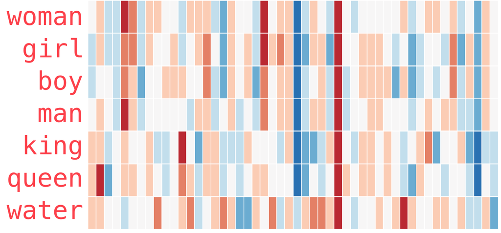

spaCy's Large English model come with GloVe (an unsupervised learning algorithm for obtaining vector representations for words) vectors trained on Common Crawl (datasets obtained from crawling the web).

```python
nlp("staff").vector
```

[output not shown]

```python
nlp("staff").vector.shape
```

```
(300,)
```

### Cosine similarity

**Cosine similarity** is a metric used to determine how similar the two vectors are by calculating the cosine of the angle between two vectors. The cosine function gives 1 at θ = 0° and -1 at θ = 180°, which means that for two overlapping vectors, cosine will be highest, while cosine will be lowest for opposite vectors. The closer the two vectors are by angle (the smaller the angle), the higher the cosine similarity.

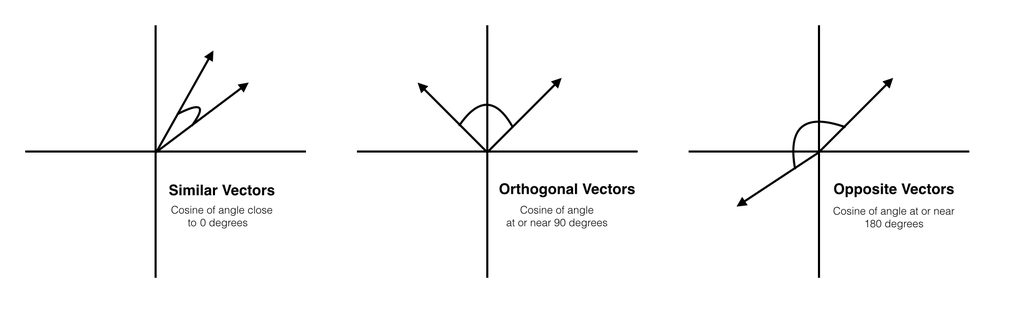

For word embeddings, if two words **frequently appear together in the same context**, then their corresponding word vectors will be **similar**. Secondly, if **there is no relation between the contexts in which each of the two words appear**, then their word vectors will be **orthogonal**. Lastly, if **there is a notable difference between the contexts in which each of the two words appear**, then their word vectors will be **opposite**.

```python
nlp("staff").similarity(nlp("employees"))
```

```
0.6675002052314796
```

Two words being antonyms does not imply their word vectors are opposite. In fact, word vectors of antonyms will generally be similar as they frequently appear together in the same context.

```python
nlp("true").similarity(nlp("false"))
```

```
0.5933783619478807
```

```python
nlp("fur").similarity(nlp("mortgage"))
```

```
0.040547008409178395
```

```python
nlp("industry").similarity(nlp("né"))
```

```
-0.20388967408634562
```

The term né, having masculine grammatical gender, can be used to denote a man's surname at birth which has subsequently been replaced or changed (e.g. Metta World Peace, né Ron Artest).

https://en.wikipedia.org/wiki/Birth_name#Maiden_and_married_names

```python
from numpy import dot
from numpy.linalg import norm

cos_sim = lambda a,b: dot(a, b)/(norm(a)*norm(b))
```

```python
cos_sim(nlp("king").vector - nlp("man").vector + nlp("woman").vector,nlp("queen").vector)
```

```
0.7880845
```